# Machine learning algorithms

Frosso Vorgia

It is now possible to collect a large amount of data about personal activity relatively inexpensively.In this project we use data from accelerometers on the belt, forearm, arm, and dumbell of 6 participants. They were asked to perform barbell lifts correctly and incorrectly in 5 different ways. More information is available from the website here: http://web.archive.org/web/20161224072740/http:/groupware.les.inf.puc-rio.br/har

## Packages

First we load the necessary packaeges and set a seed in order to reproduce the research and receive the same results.

```r
library(caret)
library(randomForest)
library(rpart)
```

```r
library(rpart.plot)
set.seed(9664)
```

## Loading the datasets

The first set will be used for training and the other for the prediction.

```r
TrainingSet <- read.csv("C:/Users/Fro/Documents/pml-training.csv", na.strings=c("NA","#DIV/0!", ""))
TestingSet <- read.csv("C:/Users/Fro/Documents/pml-testing.csv", na.strings=c("NA","#DIV/0!", ""))
```

## Cleaning

It is necessary to clean the set from too many NAs and unwanted or unnecessary information.

```r
TrainingSet<-TrainingSet[,colSums(is.na(TrainingSet)) == 0]
TestingSet <-TestingSet[,colSums(is.na(TestingSet)) == 0]
TrainingSet <-TrainingSet[,-c(1:7)]
TestingSet <-TestingSet[,-c(1:7)]
```

## Creating partitions

We can create two clean partitions. We prefer the 70 - 30 analogy for the training set.

```r
SubSamples <- createDataPartition(y=TrainingSet$classe, p=0.7, list=FALSE)
SubTraining <- TrainingSet[SubSamples, ]
SubTesting <- TrainingSet[-SubSamples, ]
dim(SubTraining)
```

```
## [1] 13737    53
```

```r
dim(SubTesting)
```

```
## [1] 5885   53
```

## The Decision Tree model

The first mla we apply is the Decision Tree.

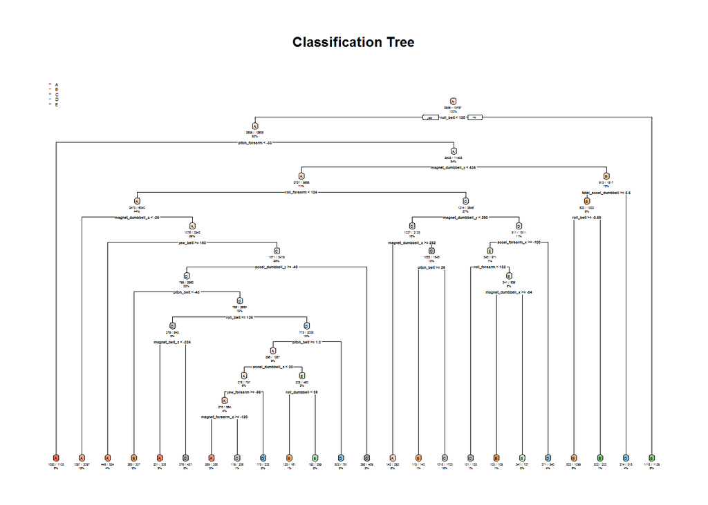

```r
ModelDecisionTree <- rpart(classe ~ ., data=SubTraining, method="class")

PredictionDecisionTree <- predict(ModelDecisionTree, SubTesting, type = "class")

rpart.plot(ModelDecisionTree, main="Classification Tree", extra=102, under=TRUE, faclen=0)
```

```r
confusionMatrix(PredictionDecisionTree, SubTesting$classe)
```

```
## Confusion Matrix and Statistics
##
##           Reference
## Prediction    A    B    C    D    E
##          A 1508  251   37  123   61
##          B   44  619   54   17   55
##          C   36  116  853  120  108
##          D   60   73   56  626   52
##          E   26   80   26   78  806
##
## Overall Statistics
##
##                Accuracy : 0.7497
##                  95% CI : (0.7384, 0.7607)
##     No Information Rate : 0.2845
##     P-Value [Acc > NIR] : < 2.2e-16
##
##                   Kappa : 0.6815
##  Mcnemar's Test P-Value : < 2.2e-16
##
## Statistics by Class:
##
##                      Class: A Class: B Class: C Class: D Class: E
## Sensitivity            0.9008   0.5435   0.8314   0.6494   0.7449
## Specificity            0.8879   0.9642   0.9218   0.9510   0.9563
## Pos Pred Value         0.7616   0.7845   0.6918   0.7220   0.7933
## Neg Pred Value         0.9575   0.8980   0.9628   0.9326   0.9433
## Prevalence             0.2845   0.1935   0.1743   0.1638   0.1839
## Detection Rate         0.2562   0.1052   0.1449   0.1064   0.1370
## Detection Prevalence   0.3364   0.1341   0.2095   0.1473   0.1726
## Balanced Accuracy      0.8944   0.7538   0.8766   0.8002   0.8506
```

## The Random Forest model

The second mla we apply is the Random Forest.

```r
ModelRandomForest <- randomForest(classe ~. , data=SubTraining, method="class")

PredictionRandomForest <- predict(ModelRandomForest, SubTesting, type = "class")

confusionMatrix(PredictionRandomForest, SubTesting$classe)
```

```
## Confusion Matrix and Statistics
##
##           Reference
## Prediction    A    B    C    D    E
##          A 1674    4    0    0    0
##          B    0 1134    8    0    0
##          C    0    1 1017   12    0
##          D    0    0    1  952    1
##          E    0    0    0    0 1081
##
## Overall Statistics
##
##                Accuracy : 0.9954
##                  95% CI : (0.9933, 0.997)
##     No Information Rate : 0.2845
##     P-Value [Acc > NIR] : < 2.2e-16
##
##                   Kappa : 0.9942
##  Mcnemar's Test P-Value : NA
##
## Statistics by Class:
##
##                      Class: A Class: B Class: C Class: D Class: E
## Sensitivity            1.0000   0.9956   0.9912   0.9876   0.9991
## Specificity            0.9991   0.9983   0.9973   0.9996   1.0000
## Pos Pred Value         0.9976   0.9930   0.9874   0.9979   1.0000
## Neg Pred Value         1.0000   0.9989   0.9981   0.9976   0.9998
## Prevalence             0.2845   0.1935   0.1743   0.1638   0.1839
## Detection Rate         0.2845   0.1927   0.1728   0.1618   0.1837
## Detection Prevalence   0.2851   0.1941   0.1750   0.1621   0.1837
## Balanced Accuracy      0.9995   0.9970   0.9943   0.9936   0.9995
```

## The prediction

```r
LastPrediction <- predict(ModelRandomForest, TestingSet, type="class")
LastPrediction
```

```
##  1  2  3  4  5  6  7  8  9 10 11 12 13 14 15 16 17 18 19 20
##  B  A  B  A  A  E  D  B  A  A  B  C  B  A  E  E  A  B  B  B
## Levels: A B C D E
```